# Writing reproducible, re-usable reports, with R + markdown

R. Burke Squires

September 7, 2021

# R Markdown

- Introduction & Overview
- Installation
- How It Works
- Components
- Lunch
- Analyze
- Share
- Reproduce

# Introduction

**Reproducible Data Science**

- In a biology wet lab researchers must keep a lab notebook - why should computational experiments be any different?
- Why do scientists keep a lab notebook?
- You should be able to go back to a coding project 10 years later, or send code to a colleague, and not only reproduce the same results - but understand why you got them!

# Literate Computing

- This isn’t a new idea – Donald Knuth published **Literate Programming** in 1983
- A single document describes an analysis using **natural language** and **code snippets**
- Mathematica implemented a notebook in 1988.
- More recently, we’ve seen a resurgence of this with IPython, now Jupyter notebooks (which support many languages).
- **R Markdown fits right into this paradigm!**

# Markdown is

plain text.

(where formatting is indicated but not immediately shown/rendered).

For example, this in Markdown:

```markdown
# Section
*my text*
```

Becomes this when rendered:

# Section

*my text*

# Rmarkdown Overview

- R Markdown provides an authoring framework for data science. You can use a single R Markdown file to both
  - save and execute code
  - generate high quality reports that can be shared
- R Markdown documents are fully reproducible and support dozens of static and dynamic output formats

# R script vs R notebook vs R markdown

It’s the exact same file format. The difference is how YOU work with it.

- R script
  - Source code (text) file containing R statements (.R extension)
- Markdown file
  - Text file containing markdown text (.md)
- R notebook
  - Interactive R file with text and code chunks (.Rmd)
- R markdown
  - Markdown document with code chunks; executed to generate output (.Rmd)

# 2. Installation

- Like the rest of R, R Markdown is free and open source
- You can install the R Markdown package from CRAN with:

  `install.packages("rmarkdown")`

=====

# 3. How It Works

How it works

- When you run render, R Markdown feeds the .Rmd file to `knitr`, which executes all of the code chunks and creates a new markdown (.md) document which includes the code and its output.
- The markdown file generated by `knitr` is then processed by `pandoc` which is responsible for creating the finished format.
- May sound complicated, but R Markdown makes it simple; single render function.

# 4. Rmarkdown Components

Open RStudio -> File -> New file -> Rmarkdown -> Click OK

What do you see? . . .

- Header
- Body
  - Narrative Text
  - Code Chunks
  - Inline Code

# Header

- YAML? . . .
- What are the options? . . . [R Markdown Reference Guide, Page 4](https://www.rstudio.com/wp-content/uploads/2015/03/rmarkdown-reference.pdf)

# Markdown Basics

# Code Chunks

When you render your .Rmd file, R Markdown will run each code chunk and embed the results beneath the code chunk in your final report.

- echo (default=TRUE): display code in the document
- eval (default=TRUE): run the code in the chunk
- tidy (default=FALSE): tidy the code displayed
- message (default=TRUE): display code messages in the document
- include (default=TRUE): include the chunk in the document
- warning (default=TRUE): display code warnings in the document

# Inline Code

```r
colorfunc <- "heat.colors"
# colorfunc <- "terrain.colors"
```

# Code Languages

`knitr` can execute code in many languages besides R. Some of the available language engines include: - Python - SQL - Bash - Rcpp - Stan - JavaScript - CSS

Note that chunk options like echo and results are all valid when using a language engine like python.

# Parameters

[RStudio.cloud Link](https://rstudio.cloud/project/181942)

R Markdown documents can include one or more parameters whose values can be set when you render the report. For example, the file below, available here, uses a data parameter that determines which data set to plot.

[figure not shown]

parameters

**Declaring Parameters** Parameters are declared using the params field within the YAML header of the document. For example, the file above creates the parameter data and assigns it the default value “hawaii”.

# Tables

# Challenge / Exercise

# Analyze

# a. Language: R, Python, SQL

# 7. Share

# a. Static, Dynamic

# b. Output Formats

# i. Notebooks

# ii. Slide Presentations

# iii. Dashboards

# iv. Websites

# v. Interactive Documents

# vi. Cheatsheets

# 8. Reproduce

# a. Learn how to publish and schedule reports

# 9. Challenge / Exercise

# 10. Conclusion

## So What is “Markdown?”

Markdown is a programming language to enable basic text files to be easily exported to (X)HTML

Created in 2004 by John Gruber in collaboration with the late Aaron Swartz

Emphasis is placed on **readability** - the **.md** or **.markdown** files can be read on their own

Markdown is an informal specification, in 2016 groups started to make formal variants: MultiMarkdown, GitHub Flavored Markdown (GFM), **Pandoc**, CommonMark, etc.

# Another Programming Language???

[figure not shown]

Another programming language?

# RELAX!

## Markdown:

Communicate your thoughts to your collaborators and your future self,

combining text, documented code,even math,

and **no fuss**.

## Source

```markdown
Text formatting
===============

Inline markup
-------------

**Paragraphs** begin and end
with empty lines, and are *not* indented.

- **bold** and *emphasis*
- ~~strikeout~~
- super^scripts^ and sub~scripts~
- and `inline_code($fixed.width)`
```

## Result

### Text formatting

#### Inline markup

**Paragraphs** begin and end with empty lines, and are *not* indented.

- **bold** and *emphasis*
- strikeout
- super<sup>scripts</sup> and sub<sub>scripts</sub>
- and `inline_code($fixed.width)`

## Source

```markdown
Lists must be preceded by an empty line,

1.  ordered or unordered.
1.  Indenting subsequent content

    -  will continue the list

        *   and nest
        *   other lists.

1.  *Indenting* means one tab, or four spaces.

After using markdown for a bit,
go read [pandoc's documentation](http://pandoc.org/README.html).
```

Lists must be preceded by an empty line,

1. ordered or unordered.
2. Indenting subsequent content
   - will continue the list
     - and nest
     - other lists.
3. *Indenting* means one tab, or four spaces.

After using markdown for a bit, go read [pandoc’s documentation](http://pandoc.org/README.html).

## Math

```
Math goes between `$`, single ($\pi$), or double:
$$ \frac{\pi}{4} = \sum_{n=0}^\infty \frac{(-1)^n}{2k+1} .$$
```

Math goes between `$`, single ($\pi$), or double:
$$\frac{\pi}{4} = \sum_{n=0}^\infty \frac{(-1)^n}{2k+1} .$$

Even math environments *inside* double dollar signs:

```markdown
$$
\begin{align}
    x &= (a+b)^2 - (a-b)^2 \\
      &= 4ab
\end{align}
$$
```

$$\begin{align}
x &= (a+b)^2 - (a-b)^2 \\
&= 4ab
\end{align}$$

## Code blocks

````
```{.r}
msg <- "Hello, world."
print(msg)
```
````

**produces**

```r
msg <- "Hello, world."
print(msg)
```

## Blockquotes

```
> I also dream about a modern replacement for LaTeX
> designed from the ground up to target multiple output formats
> (at least PDF, HTML, EPUB). -- [John MacFarlane](http://john.macfarlane.usesthis.com/)
```

**produces**

> I also dream about a modern replacement for LaTeX designed from the ground up to target multiple output formats (at least PDF, HTML, EPUB). – [John MacFarlane](http://john.macfarlane.usesthis.com/)

## Links and Images

A [link](https://rmarkdown.rstudio.com) just go in parentheses, and can be internal.

```markdown
A [link](https://rmarkdown.rstudio.com) just go in parentheses,
and can be [internal](#links-and-images).
```

Images are **the same** but with a `!` in front.  
Setting width and height are optional.

[figure not shown]

oh, internet

```markdown
![oh, internet](cat-pandoc.jpg){width=300px height=300px}
```

# Anatomy of an R Markdown File

Notice that the file contains three types of content:

- An (optional) YAML header surrounded by —
- R code chunks surrounded by ```
- Text mixed with simple text formatting

## Header

**Header** in YAML format with: - Three dashes (to open) - Title - Author - Date - Output format(s)(Used for compiling - multiple output formats can be written here!) - Three dashes (to close)

# Body

The main Markdown and code content Code chunks are offset by ``` before/after

## Gotchas

1. many things need to begin with an empty line
2. carriage returns don’t (usually) mean anything
3. but indentations do (*by at least four spaces*)

For more info see [the documentation](http://pandoc.org/README.html#the-four-space-rule).

## Metadata

At the top of your document, add

```yaml
---
title: YOUR TITLE HERE
author: YOUR NAME HERE
date: August 23, 2017
---
```

… the [YAML](http://yaml.org/) metadata,  
delimited by **exactly three** dashes.

**Note:** Besides setting the title, you can control the **output** in [many](http://tex.stackexchange.com/questions/139139/adding-headers-and-footers-using-pandoc/139205#139205) [ways](http://rmarkdown.rstudio.com/html_document_format.html#pandoc-arguments) here.

*For example*: add

```yaml
output_format : pdf_document
```

and render with `rmarkdown::render("notes.md")`.

**or even:**

```yaml
output_format : word_document
```

## Under the hood

[`pandoc`](http://pandoc.org/README.html)

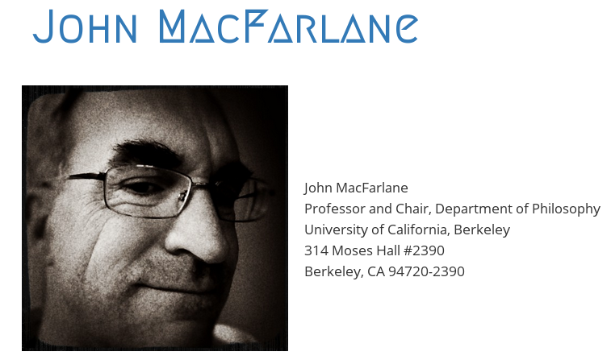

jgm

```bash
pandoc --help
```

# Adding in R

**Goal:** add R code to the document, *along with its output*.

[figure not shown]

knitr

## Go ahead

Just add a *chunk* of R code, wrapped in

````
 ```r
 # PUT ARBITRARY R CODE HERE
 ```
````

**Try it!**

````
Powers of two?


 ```r
 2^(0:10)
 ```

 ```
 ##  [1]    1    2    4    8   16   32   64  128  256  512 1024
 ```
````

Powers of two?

```r
2^(0:10)
```

```
##  [1]    1    2    4    8   16   32   64  128  256  512 1024
```

````
How about this?
$$ \lim_{n \to \infty} 4 \sum_{k=1}^n \frac{ (-1)^n }{ 2n+1 } = \pi , $$


 ```r
 cumsum( 4 * (-1)^(0:20) / (2*(0:20)+1) )
 ```

 ```
 ##  [1] 4.000000 2.666667 3.466667 2.895238 3.339683 2.976046 3.283738 3.017072
 ##  [9] 3.252366 3.041840 3.232316 3.058403 3.218403 3.070255 3.208186 3.079153
 ## [17] 3.200366 3.086080 3.194188 3.091624 3.189185
 ```
````

```r
cumsum( 4 * (-1)^(0:20) / (2*(0:20)+1) )
```

```
##  [1] 4.000000 2.666667 3.466667 2.895238 3.339683 2.976046 3.283738 3.017072
##  [9] 3.252366 3.041840 3.232316 3.058403 3.218403 3.070255 3.208186 3.079153
## [17] 3.200366 3.086080 3.194188 3.091624 3.189185
```

````
 ```r
 plot(cumsum( 4 * (-1)^(0:20) / (2*(0:20)+1) ))
 abline(h=pi, col='red')
 ```

 <img src="using-rmarkdown_files/figure-slidy/unnamed-chunk-8-1.png" width="768" />
````

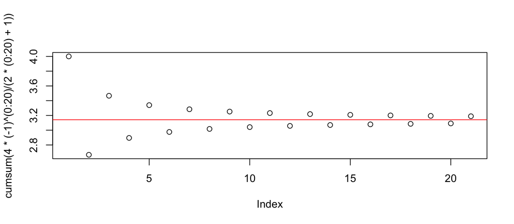

```r
plot(cumsum( 4 * (-1)^(0:20) / (2*(0:20)+1) ))
abline(h=pi, col='red')
```

## Exercise

Make a short Rmarkdown document that

- checks that
  $$1 + 2 + \cdots + n = n(n+1)/2$$
  for every $n$ between 1 and 100
- shows these on a plot
- explains what’s being computed

*Useful:* `x = cumsum(1:100)` and `plot(x)` and `lines(y)`.

## What’s going on

1. `knitr` uses a *regular expression* to find code chunks
   - pulls these out,
   - evaluates them one at a time
   - and inserts “the results” back in
2. `pandoc` renders the resulting markdown file
   - with various choices of styling

## Chunk options

Name each chunk, and set [options](http://yihui.name/knitr/options/) for [what gets printed](http://yihui.name/knitr/demo/output/)

[output not shown]

## Tables

One option: use `pander`.

````
 ```r
 library(pander)
 bases <- table( sample( c("A","C","G","T"), 300, replace=TRUE ) )
 pander(t(bases))
 ```


 -------------------
  A    C    G    T
 ---- ---- ---- ----
  77   71   66   86
 -------------------
````

*note:* the transpose `t( )`

```r
 library(pander)
 bases <- table( sample( c("A","C","G","T"), 300, replace=TRUE ) )
 pander(t(bases))
```

| A | C | G | T |
| --- | --- | --- | --- |
| 69 | 59 | 84 | 88 |

## Inline code

```
You can
`r paste(letters[c(9,14,19,5,18,20)],collapse='')`
code anywhere.
```

You can insert code anywhere.

Even in the YAML header.

Go change yours!

```
---
title: "My notes"
author: "Peter Ralph"
date: "`r date()`"
---
```